# [Group 20] Final Project

Elisa Mateos, Sebastian Skoczeń, Serena Alderisi, Yass Al Bahri

## Introduction and Related Work

Since the beginning of civilisation, knowledge was considered to be invaluable. “You give a poor man a fish and you feed him for a day. You teach him to fish and you give him an occupation that will feed him for a lifetime.” - a saying that has roots in the ancient chainese culture is one of the causes of this perspective. Nowadays with the current data availability and technologies, we are able to actually check what is the influence of the education on tested population. In this work, we will focus on United States citizens because of big amounts of reliable data gathered by the U.S. Census Bureau and U.S. Bureau of Labor Statistics.

In 2018 over 69% of Americans had a college degree, over 43% of them obtained a bachelor’s degree, finally 26% and 6.5% of those with a bachelor’s degree obtained master’s and doctoral degree respectively. This compares to 42.9% of the population that had a college degree in 1992 and a huge increase from only 25% of the population that had a college degree in 1940.<sup>1</sup> Additionally George Psacharopoulos in his article concluded that a high school dropout earns about $260,000 less over a lifetime than a high school graduate which can have a significant effect on the household income overall.<sup>2</sup> Education in the U.S., however, is an expensive investment, frequently reaching hundreds of thousands of dollars and a lot of Americans are asking themselves a question if it’s worth it.

Another factor that is influencing education among the population is the distribution of finances and state spendings on this matter. The research conducted by Murray, William and Schwab indicates that the financial reform that took place over 20 years ago, led states to increase spending for education and leave spending in other areas unchanged, and thus by implication states fund the additional spending on education through higher taxes.<sup>3</sup> It clearly shows that the reform forced increased financing of the educational sector, expecting revenue of the investment in the long run.

Looking at the past years the unemployment rate at the beginning of 1992 was on the 7.3% level compared to 4.1% in January 2018. However, as Montgomery, Zarnowitz and Tiao are proving in their work, over the last century, the U.S. unemployment rate (u) had no consistent trend at all, clearly indicating that it’s dependant on much more variables than just education itself.<sup>4</sup>

Finally, median household income varies based on the educational attainment of the household head and if led by an individual over 25 years of age with a bachelor’s degree or more have incomes that are considerably higher than the national median.<sup>5</sup> This shows a pretty clear correlation, however it does not indicate if educational finances affected this or if the labour market itself did.

Thus the aim of this work is to check how and if the educational finances and the household income affects the unemployment rate in the U.S. For the purpose of this work, a “state” level of granularity has been chosen to represent in a more detailed way the differences between states.

## Exploratory Data Analysis

Starting from three different data sets, A new data frame is created for this study, based on a selection From the previous data sets. Median income in current dollars is picked from the Mean and Median data set. From the unemployment data set, the Unemployment rate by stated is included. From the U.S. Educational Finances, the variables kept for this study are the following:

- Total revenue
- Federal revenue
- State revenue
- Local revenue
- Total expenditure
- Instruction expenditure
- Support services expenditure
- Other expenditure
- Capital outlay expenditure

Additionally, the data set is normalized for the values of States and year.

After cleaning the dataset we proceed to explore it visually.

[figure not shown]

[figure not shown]

1. First of all, to get a grasp of how unemployment affected the US in the last two decades, a couple of simple representations are plotted.

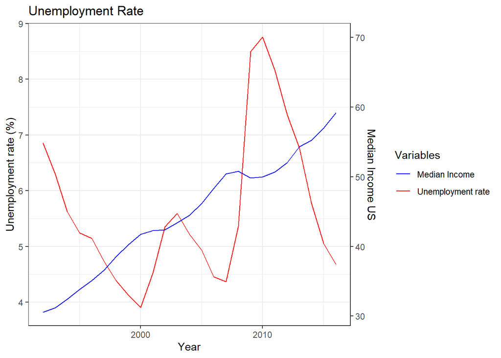

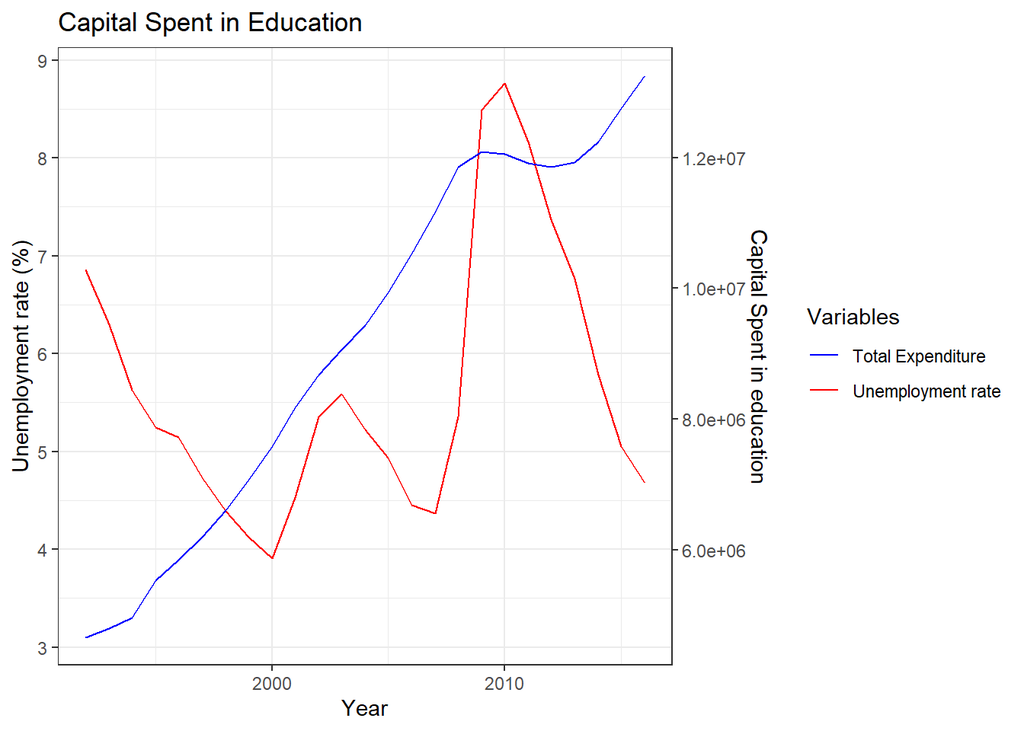

2. Calculate the average of Unemployment by state

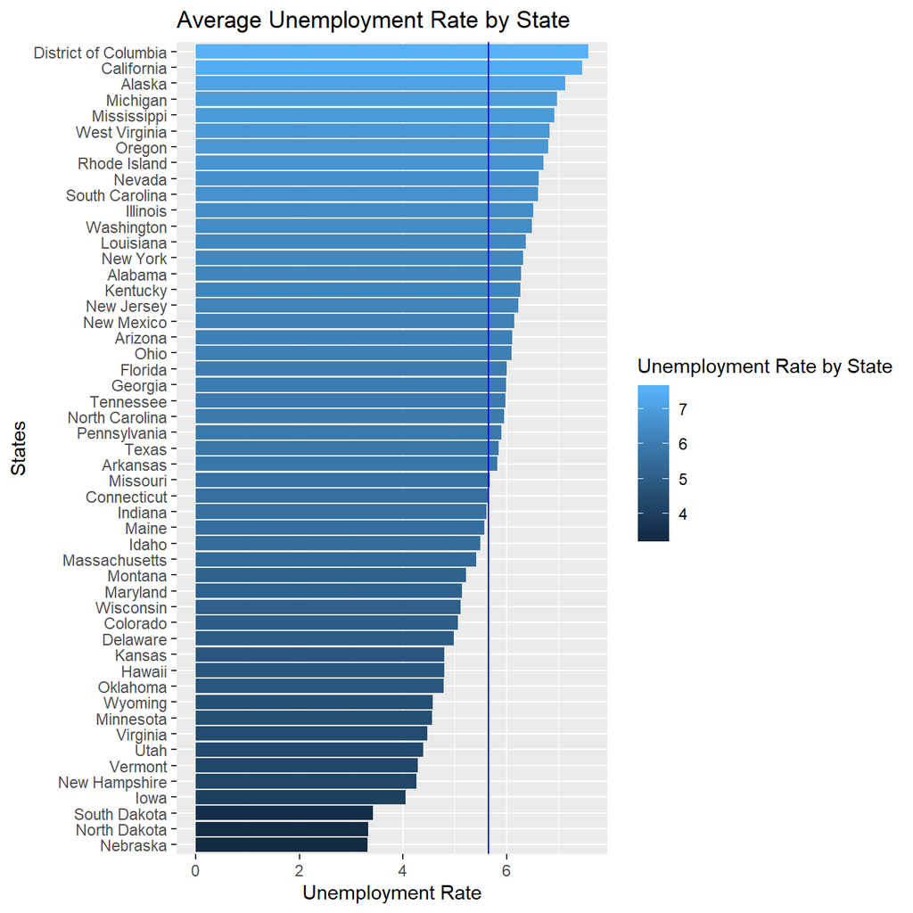

This plot is a ranking of the states from the highest to the lowest unemployment rate. This is done by calculating the average of this variable throught the years.

3. Calculate the average of Median Income by state

[figure not shown]

Similar to the previous one, this plot is a ranking of the states. In this case they are ranked based on the average median household income in the last two decades.

## Methods

**Strength of relationships**

```r
finances <- read.csv("./data/merged_dataset.csv",head=TRUE, sep=";",dec=",",stringsAsFactors=FALSE)
finances$STATE <- as.factor(finances$STATE)
```

Before to analyse the strength of relationships between the variables, a new variable is added to the dataset: Profit. Profit is the difference between the Total Revenue and the Total Expenditure, so actually the value that give us information about the economic resources available in a State for the Education.

```r
finances$Profit<-finances$TOTAL_REVENUE-finances$TOTAL_EXPENDITURE
```

Since the question of interest is “How does education finances and household income affect the unemployment rate?”, the responce variable is The Unemployment Rate and the indipendent variables are Household Income and Profit, the new one. We suspect that these variables might affect the Unemployment rate so we checked their relationship with the response variables

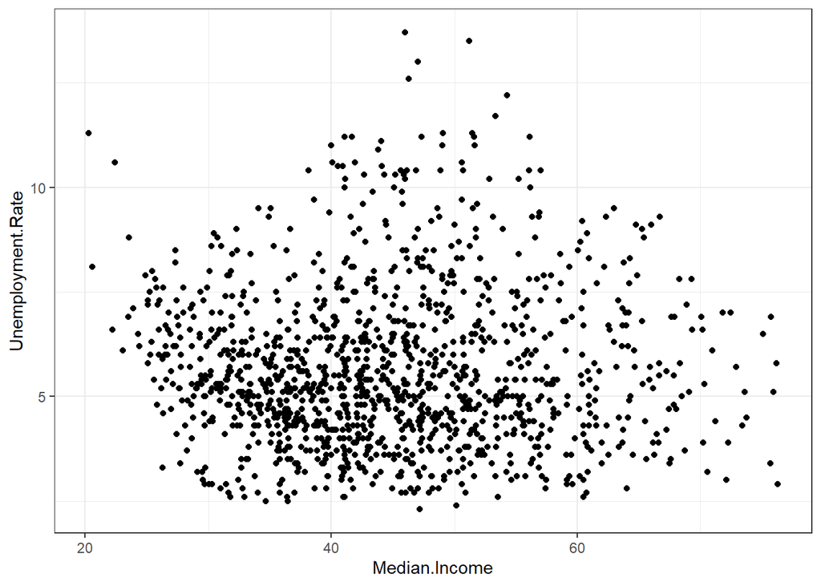

```r
library(ggplot2)
ggplot(data = finances) +
  aes(x = Median.Income, y = Unemployment.Rate)+
  geom_point()
```

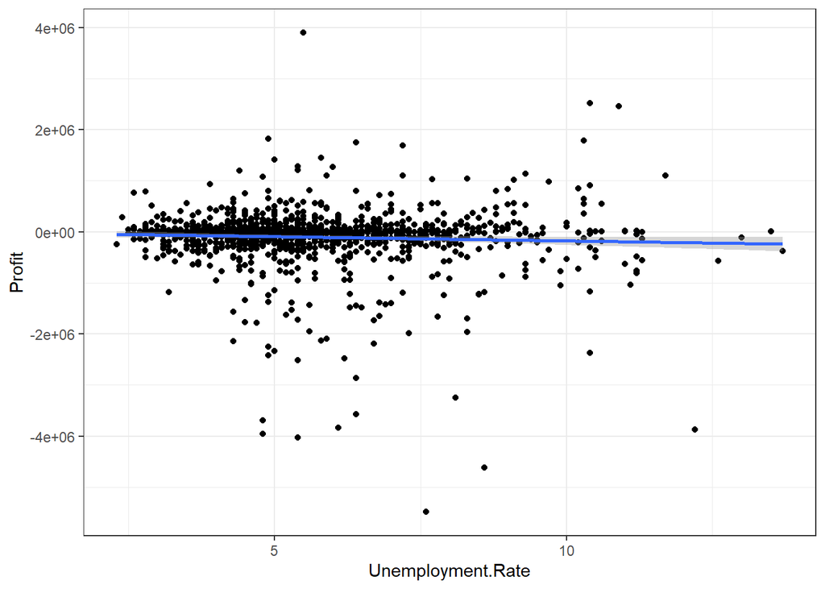

```r
ggplot(data = finances) +
  aes(x = Unemployment.Rate , y = Profit)+
  geom_point()+geom_smooth(method='lm')
```

```r
numeric_subset<-select(finances, Profit, Median.Income, Unemployment.Rate)
M<-cor(numeric_subset)
M
```

```
##                        Profit Median.Income Unemployment.Rate
## Profit             1.00000000   0.051900774      -0.054036741
## Median.Income      0.05190077   1.000000000       0.005814948
## Unemployment.Rate -0.05403674   0.005814948       1.000000000
```

The question of interest is “How does education finances and household income affect the unemployment rate?”, but since the linear regression line on the scatter plot seems affected by the choise of considering The Unemployment Rate as response variable and the Household Income as indipendent variables, the Y becomes Profit and the X becomes Unemployment Rate.

The linear regression is performed:

Profit= Beta0 + Beta1 * Unemployment Rate

```r
mod<-lm(finances$Profit ~ finances$Unemployment.Rate)
summary(mod)
```

```
##
## Call:
## lm(formula = finances$Profit ~ finances$Unemployment.Rate)
##
## Residuals:
##      Min       1Q   Median       3Q      Max
## -5351199   -72548    71557   162850  3998879
##
## Coefficients:
##                            Estimate Std. Error t value Pr(>|t|)
## (Intercept)                  -10628      51055  -0.208   0.8351
## finances$Unemployment.Rate   -16568       8581  -1.931   0.0537 .
## ---
## Signif. codes:  0 '***' 0.001 '**' 0.01 '*' 0.05 '.' 0.1 ' ' 1
##
## Residual standard error: 573700 on 1273 degrees of freedom
## Multiple R-squared:  0.00292,    Adjusted R-squared:  0.002137
## F-statistic: 3.728 on 1 and 1273 DF,  p-value: 0.05373
```

The Rsquared it’s pretty low so it means that this model is not a good model. To check that, the next step is the validation of the assumptions on which the regression model is based on: Normality of the residuals, Homoskedasticity of the residuals and Indipendence between the residuals.

```r
library(tseries)
library(lmtest)
jarque.bera.test(mod$residuals)
```

```
##
##  Jarque Bera Test
##
## data:  mod$residuals
## X-squared = 25937, df = 2, p-value < 2.2e-16
```

```r
bptest(mod)
```

```
##
##  studentized Breusch-Pagan test
##
## data:  mod
## BP = 17.612, df = 1, p-value = 2.708e-05
```

```r
dwtest(mod)
```

```
##
##  Durbin-Watson test
##
## data:  mod
## DW = 1.9381, p-value = 0.1315
## alternative hypothesis: true autocorrelation is greater than 0
```

The next step is scaling the value since they have very different range and value and perform again the regression

```r
finances$new_profit=scale(finances$Profit)
finances$new_rate=scale(finances$Unemployment.Rate)
mod2<-lm(finances$new_profit ~ finances$new_rate)
summary(mod2)
```

```
##
## Call:
## lm(formula = finances$new_profit ~ finances$new_rate)
##
## Residuals:
##     Min      1Q  Median      3Q     Max
## -9.3172 -0.1263  0.1246  0.2835  6.9626
##
## Coefficients:
##                     Estimate Std. Error t value Pr(>|t|)
## (Intercept)        1.065e-17  2.798e-02   0.000   1.0000
## finances$new_rate -5.404e-02  2.799e-02  -1.931   0.0537 .
## ---
## Signif. codes:  0 '***' 0.001 '**' 0.01 '*' 0.05 '.' 0.1 ' ' 1
##
## Residual standard error: 0.9989 on 1273 degrees of freedom
## Multiple R-squared:  0.00292,    Adjusted R-squared:  0.002137
## F-statistic: 3.728 on 1 and 1273 DF,  p-value: 0.05373
```

```r
#residuals test
jarque.bera.test(mod2$residuals)
```

```
##
##  Jarque Bera Test
##
## data:  mod2$residuals
## X-squared = 25937, df = 2, p-value < 2.2e-16
```

```r
bptest(mod2)
```

```
##
##  studentized Breusch-Pagan test
##
## data:  mod2
## BP = 17.612, df = 1, p-value = 2.708e-05
```

```r
dwtest(mod2)
```

```
##
##  Durbin-Watson test
##
## data:  mod2
## DW = 1.9381, p-value = 0.1315
## alternative hypothesis: true autocorrelation is greater than 0
```

- **Prediction**:

```r
# Libraries
library(ggplot2)
library(caret)
library(stats)
library(dplyr)
library(plotly)
library(hrbrthemes)
library(rgl)
library(lattice)

finances <- read.csv("./data/merged_dataset.csv",head=TRUE, sep=";",dec=",")

sum(is.na(finances))
```

```
## [1] 102
```

```r
us_finances <- na.omit(finances)
sum(is.na(us_finances))
```

```
## [1] 0
```

```r
unemployment_rate <- us_finances$Unemployment.Rate
us_finances <- mutate(us_finances, unemployment_rate)
summary(us_finances)
```

```
##         STATE           YEAR          ENROLL        TOTAL_REVENUE
##  Alabama   :  24   Min.   :1993   Min.   :  43866   Min.   :  465650
##  Alaska    :  24   1st Qu.:1999   1st Qu.: 264514   1st Qu.: 2224650
##  Arizona   :  24   Median :2004   Median : 649934   Median : 5256748
##  Arkansas  :  24   Mean   :2004   Mean   : 917542   Mean   : 9290765
##  California:  24   3rd Qu.:2010   3rd Qu.:1010532   3rd Qu.:11109870
##  Colorado  :  24   Max.   :2016   Max.   :6307022   Max.   :89217262
##  (Other)   :1080
##  FEDERAL_REVENUE   STATE_REVENUE      LOCAL_REVENUE      TOTAL_EXPENDITURE
##  Min.   :  33672   Min.   :       0   Min.   :   23917   Min.   :  481665
##  1st Qu.: 193102   1st Qu.: 1191590   1st Qu.:  738018   1st Qu.: 2211494
##  Median : 421910   Median : 2614030   Median : 2098524   Median : 5415694
##  Mean   : 787394   Mean   : 4312719   Mean   : 4190651   Mean   : 9395936
##  3rd Qu.: 847927   3rd Qu.: 5224320   3rd Qu.: 4793464   3rd Qu.:10892861
##  Max.   :9990221   Max.   :50904567   Max.   :36105265   Max.   :85320133
##
##  INSTRUCTION_EXPENDITURE SUPPORT_SERVICES_EXPENDITURE OTHER_EXPENDITURE
##  Min.   :  265549        Min.   :  139963             Min.   :  11541
##  1st Qu.: 1195616        1st Qu.:  652780             1st Qu.: 103449
##  Median : 2737071        Median : 1567025             Median : 271704
##  Mean   : 4864428        Mean   : 2737271             Mean   : 429951
##  3rd Qu.: 5648436        3rd Qu.: 3308660             3rd Qu.: 517222
##  Max.   :43964520        Max.   :26058021             Max.   :3995951
##
##  CAPITAL_OUTLAY_EXPENDITURE Median.Income   Unemployment.Rate unemployment_rate
##  Min.   :   12708           Min.   :22.19   Min.   : 2.300    Min.   : 2.300
##  1st Qu.:  188692           1st Qu.:37.28   1st Qu.: 4.300    1st Qu.: 4.300
##  Median :  529592           Median :44.39   Median : 5.300    Median : 5.300
##  Mean   :  924237           Mean   :45.27   Mean   : 5.597    Mean   : 5.597
##  3rd Qu.:  990893           3rd Qu.:51.84   3rd Qu.: 6.600    3rd Qu.: 6.600
##  Max.   :10223657           Max.   :76.26   Max.   :13.700    Max.   :13.700
##
```

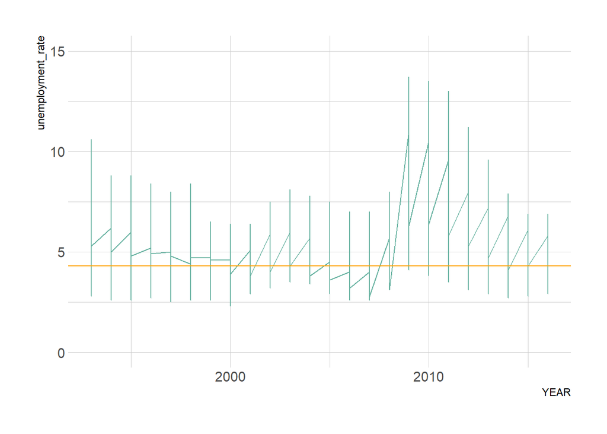

```r
# plot
us_finances %>%
  ggplot( aes(x= YEAR, y= unemployment_rate)) +
  geom_line(color="#69b3a2") +
  ylim(0,15) +
  geom_hline(yintercept=4.3, color="orange", size=.5) +
  theme_ipsum()
```

- Splitting your data into testing/training data

In order to carry out these algorithms, first you go through the phase of testing and training the data. In our case we used 80% in the training phase and 20% in the testing. The *createDataPartition* function is used for the training phase.

```r
trainIndex <- createDataPartition(us_finances$unemployment,
                                  p = .8,
                                  list = FALSE,
                                  times = 1
)
```

- Applying cross validation to your model

Cross-validation is a statistical method used to estimate the skill of machine learning models. To carry out cross-validation, the function *trainControl*( method = “cv”) and the number of times you want to do it are defined. Afterwards, the same training and testing process as before is carried out again.

```r
fitControl <- trainControl(
  method = "cv",
  number = 10
)
```

- Appropriately handling any missing values

Before performing the training and extinguishing process, a cleaning process has been carried out, in which the missing values have been eliminated and transformed from the database so that the prediction is much clearer.

```r
sum(is.na(finances))
```

```
## [1] 102
```

```r
us_finances <- na.omit(finances)
```

- Appropriately using categorical variables

The use of categorical variables in Machine Learning algorithms is necessary, so at the beginning of its implementation a transformation of the variable of interest to categorical values was performed, leaving the other variables as *int* or *num*.

```r
unemployment <- ifelse( us_finances$Unemployment.Rate >= 4.3, "True", "False")
us_finances <- mutate(us_finances, unemployment)
```

- Using a grid search to find the best parameters for you model of interest

In order to compare which model is the best, many statistical measures can be made, such as Benchmark, but in this work we have made the ConfusionMatrix, which shows the **True Negative**, **True Positive**, **False Negative** and **False Positive** of the classification method we have performed. In this way the accuracy of the model can be obtained and it can be compared with those of the other models also implemented. The kappa statistician is also a good meter to obtain the reliability of the model.

- Employing the algorithm of interest

As indicated at the beginning of this section, three algorithms have been applied to predict the variable of interest. *K-Nearest Neighbors*, *Logistic Regression* and *Classification Trees*. At the bottom you can see how each of the algorithms has been implemented.

**KNN**

```r
fit_cv_grid <- caret::train(
  unemployment ~ .,
  data = training_set,
  method = "knn",
  trControl = fitControl,
  tuneGrid = grid
)
```

**Logistic Regression**

```r
getParamSet("classif.logreg")
```

```
##          Type len  Def Constr Req Tunable Trafo
## model logical   - TRUE      -   -   FALSE     -
```

```r
learner_log <- makeLearner("classif.logreg",
                           predict.type = "response")
```

**Classification Tree**

```r
getParamSet("classif.rpart")
```

```
##                    Type len  Def   Constr Req Tunable Trafo
## minsplit        integer   -   20 1 to Inf   -    TRUE     -
## minbucket       integer   -    - 1 to Inf   -    TRUE     -
## cp              numeric   - 0.01   0 to 1   -    TRUE     -
## maxcompete      integer   -    4 0 to Inf   -    TRUE     -
## maxsurrogate    integer   -    5 0 to Inf   -    TRUE     -
## usesurrogate   discrete   -    2    0,1,2   -    TRUE     -
## surrogatestyle discrete   -    0      0,1   -    TRUE     -
## maxdepth        integer   -   30  1 to 30   -    TRUE     -
## xval            integer   -   10 0 to Inf   -   FALSE     -
## parms           untyped   -    -        -   -    TRUE     -
```

```r
learner_bctree <- makeLearner("classif.rpart",
                              predict.type = "response")
```

## Results

- **Strength of relationships**:

- **Predictions**:

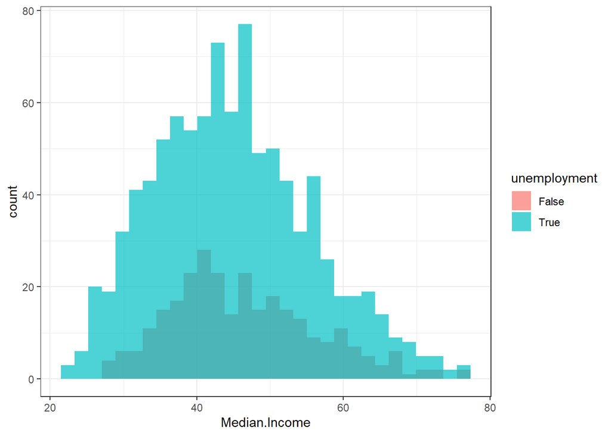

```r
ggplot(data = us_finances) +
  geom_histogram(
    mapping = aes(x = Median.Income, fill = unemployment),
    alpha = .7,
    position = "identity"
  )
```

Before starting the analysis, it is important to clean and prepare the data.

```r
# Define the variable unemployment as True or False. We are going to focus on the 1st Qu.

unemployment <- ifelse( us_finances$unemployment_rate >= 4.3, "True", "False")

us_finances <- mutate(us_finances, unemployment)

# MACHINE LEARNING

task <- makeClassifTask(id = "US Finances", data = us_finances,
                        target = "unemployment", positive = "True")
task # Analysis the data
```

```
## Supervised task: US Finances
## Type: classif
## Target: unemployment
## Observations: 1224
## Features:
##    numerics     factors     ordered functionals
##          13           1           0           0
## Missings: FALSE
## Has weights: FALSE
## Has blocking: FALSE
## Has coordinates: FALSE
## Classes: 2
## False  True
##   287   937
## Positive class: True
```

**KNN**

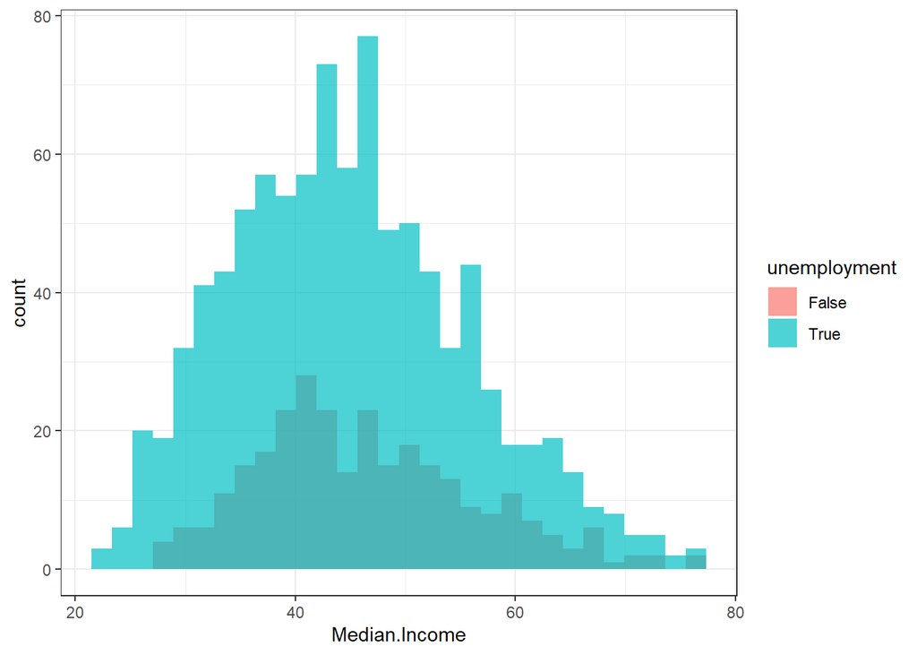

```r
unemployment_rate <- as.numeric(us_finances$Unemployment.Rate)
us_finances <- mutate(us_finances, unemployment_rate)
ggplot(data = us_finances) +
  geom_histogram(
    mapping = aes(x = Median.Income, fill = unemployment),
    alpha = .7,
    position = "identity"
  )
```

```r
# Training
trainIndex <- createDataPartition(us_finances$unemployment,
                                  p = .8,
                                  list = FALSE,
                                  times = 1
)

training_set <- us_finances[ trainIndex, ]
test_set <- us_finances[ -trainIndex, ]

basic_fit <- caret::train(data = training_set,unemployment ~ .,method = "knn")

basic_preds <- predict(basic_fit, test_set)

fitControl <- trainControl(
  method = "cv",
  number = 10
)

fit_with_cv <- caret::train(
  unemployment ~ .,
  data = training_set,
  method = "knn",
  trControl = fitControl
)


fit_cv_preds <- predict(fit_with_cv, test_set)

unemployment_factor <- as.factor(test_set$unemployment)

confusionMatrix(unemployment_factor, fit_cv_preds, positive = "True")
```

```
## Confusion Matrix and Statistics
##
##           Reference
## Prediction False True
##      False    23   34
##      True      7  180
##
##                Accuracy : 0.832
##                  95% CI : (0.779, 0.8766)
##     No Information Rate : 0.877
##     P-Value [Acc > NIR] : 0.9846
##
##                   Kappa : 0.4382
##
##  Mcnemar's Test P-Value : 4.896e-05
##
##             Sensitivity : 0.8411
##             Specificity : 0.7667
##          Pos Pred Value : 0.9626
##          Neg Pred Value : 0.4035
##              Prevalence : 0.8770
##          Detection Rate : 0.7377
##    Detection Prevalence : 0.7664
##       Balanced Accuracy : 0.8039
##
##        'Positive' Class : True
##
```

```r
grid <- expand.grid(k = 1:20)

fit_cv_grid <- caret::train(
  unemployment ~ .,
  data = training_set,
  method = "knn",
  trControl = fitControl,
  tuneGrid = grid
)

preds_cv_grid <- predict(fit_cv_grid, test_set)

confusionMatrix(unemployment_factor, preds_cv_grid, positive = "True")
```

```
## Confusion Matrix and Statistics
##
##           Reference
## Prediction False True
##      False    29   28
##      True     14  173
##
##                Accuracy : 0.8279
##                  95% CI : (0.7745, 0.873)
##     No Information Rate : 0.8238
##     P-Value [Acc > NIR] : 0.47373
##
##                   Kappa : 0.4744
##
##  Mcnemar's Test P-Value : 0.04486
##
##             Sensitivity : 0.8607
##             Specificity : 0.6744
##          Pos Pred Value : 0.9251
##          Neg Pred Value : 0.5088
##              Prevalence : 0.8238
##          Detection Rate : 0.7090
##    Detection Prevalence : 0.7664
##       Balanced Accuracy : 0.7676
##
##        'Positive' Class : True
##
```

**Classification Tree**

```r
ParamHelpers::getParamSet("classif.rpart")
```

```
##                    Type len  Def   Constr Req Tunable Trafo
## minsplit        integer   -   20 1 to Inf   -    TRUE     -
## minbucket       integer   -    - 1 to Inf   -    TRUE     -
## cp              numeric   - 0.01   0 to 1   -    TRUE     -
## maxcompete      integer   -    4 0 to Inf   -    TRUE     -
## maxsurrogate    integer   -    5 0 to Inf   -    TRUE     -
## usesurrogate   discrete   -    2    0,1,2   -    TRUE     -
## surrogatestyle discrete   -    0      0,1   -    TRUE     -
## maxdepth        integer   -   30  1 to 30   -    TRUE     -
## xval            integer   -   10 0 to Inf   -   FALSE     -
## parms           untyped   -    -        -   -    TRUE     -
```

```r
learner_bctree <- mlr::makeLearner("classif.rpart",
                              predict.type = "response")
learner_bctree$par.set #same as getparamset
```

```
##                    Type len  Def   Constr Req Tunable Trafo
## minsplit        integer   -   20 1 to Inf   -    TRUE     -
## minbucket       integer   -    - 1 to Inf   -    TRUE     -
## cp              numeric   - 0.01   0 to 1   -    TRUE     -
## maxcompete      integer   -    4 0 to Inf   -    TRUE     -
## maxsurrogate    integer   -    5 0 to Inf   -    TRUE     -
## usesurrogate   discrete   -    2    0,1,2   -    TRUE     -
## surrogatestyle discrete   -    0      0,1   -    TRUE     -
## maxdepth        integer   -   30  1 to 30   -    TRUE     -
## xval            integer   -   10 0 to Inf   -   FALSE     -
## parms           untyped   -    -        -   -    TRUE     -
```

```r
mod_bctree <- mlr::train(learner_bctree, task)
getLearnerModel(mod_bctree)
```

```
## n= 1224
##
## node), split, n, loss, yval, (yprob)
##       * denotes terminal node
##
## 1) root 1224 287 True (0.2344771 0.7655229)
##   2) Unemployment.Rate< 4.25 287   0 False (1.0000000 0.0000000) *
##   3) Unemployment.Rate>=4.25 937   0 True (0.0000000 1.0000000) *
```

```r
predict_bctree <- predict(mod_bctree, task = task)
head(as.data.frame(predict_bctree))
```

|  | id | truth | response |
| --- | --- | --- | --- |
| 1 | 1 | True | True |
| 2 | 2 | True | True |
| 3 | 3 | True | True |
| 4 | 4 | True | True |
| 5 | 5 | True | True |
| 6 | 6 | True | True |

```r
conf_matrix_bctree <- calculateConfusionMatrix(predict_bctree)
conf_matrix_bctree
```

```
##         predicted
## true     False True -err.-
##   False    287    0      0
##   True       0  937      0
##   -err.-     0    0      0
```

```r
conf_matrix_bctree <- calculateConfusionMatrix(predict_bctree)
conf_matrix_bctree
```

```
##         predicted
## true     False True -err.-
##   False    287    0      0
##   True       0  937      0
##   -err.-     0    0      0
```

## Discussion and Future Work

## References

1. https://learningenglish.voanews.com/a/us-census-bureau-americans-are-more-educated-than-ever-before/4546489.html
2. Psacharopoulos, George. (2006). The Value of Investment in Education: Theory, Evidence and Policy. http://lst-iiep.iiep-unesco.org/cgi-bin/wwwi32.exe/[in=epidoc1.in]/?t2000=024211/(100). 32.
3. Evans, William & Murray, Sheila & Schwab, Robert. (1998). Education-Finance Reform and the Distribution of Education Resources. American Economic Review. 88. 789-812.
4. Alan L. Montgomery, Victor Zarnowitz, Ruey S. Tsay & George C. Tiao (1998) Forecasting the U.S. Unemployment Rate, Journal of the American Statistical Association, 93:442, 478-493, DOI: 10.1080/01621459.1998.10473696
5. https://www.pgpf.org/blog/2019/10/income-and-wealth-in-the-united-states-an-overview-of-data

## Authors

- Elisa Mateos
- Sebastian Skoczeń
- Serena Alderisi
- Yass Al Bahri